# TP1_Berte_math_applied

## Master Mathematics Appliquées, Statistique - Parcours Data Science.

## Course Applied mathematics

## TP. Introduction to the library optimize of Scipy.

## Frédéric Richard, AMU, 2024

### 0. Library used in this TP.

```python
import pandas as pd
import numpy as np
import matplotlib.pyplot as plt
import scipy.optimize as optim
```

### 1. Introduction.

### 1.1. Context and goal.

The educational goal of the project is to learn how to manipulate methods of the module optimize from the scientific computing package Scipy, and apply them to real-world examples. The examined methods include *lsq_linear*, and *least_squares*. These methods will be applied in the context of a climate study for the trend analysis of a time serie of temperature changes over the recent years.

### 1.2. Data.

```python
import pandas as pd

# Ajoutez le chemin complet au fichier avec son extension
file_path = r"C:\Users\DELL\Downloads\TP 1 - material\climate_change.csv"

# Charger le fichier CSV
climate_data = pd.read_csv(r"C:\Users\DELL\Downloads\TP 1 - material\climate_change.csv", sep=",")
print(climate_data.columns)
```

```
Index(['ObjectId', 'Country', 'ISO2', 'ISO3', 'Indicator', 'Unit', 'Source',
       'CTS_Code', 'CTS_Name', 'CTS_Full_Descriptor', 'F1961', 'F1962',
       'F1963', 'F1964', 'F1965', 'F1966', 'F1967', 'F1968', 'F1969', 'F1970',
       'F1971', 'F1972', 'F1973', 'F1974', 'F1975', 'F1976', 'F1977', 'F1978',
       'F1979', 'F1980', 'F1981', 'F1982', 'F1983', 'F1984', 'F1985', 'F1986',
       'F1987', 'F1988', 'F1989', 'F1990', 'F1991', 'F1992', 'F1993', 'F1994',
       'F1995', 'F1996', 'F1997', 'F1998', 'F1999', 'F2000', 'F2001', 'F2002',
       'F2003', 'F2004', 'F2005', 'F2006', 'F2007', 'F2008', 'F2009', 'F2010',
       'F2011', 'F2012', 'F2013', 'F2014', 'F2015', 'F2016', 'F2017', 'F2018',
       'F2019', 'F2020', 'F2021', 'F2022'],
      dtype='object')
```

One of the dataset entries gives the evolution of temperatures on average for all the countries. This entries can be selected and plotted as follows.

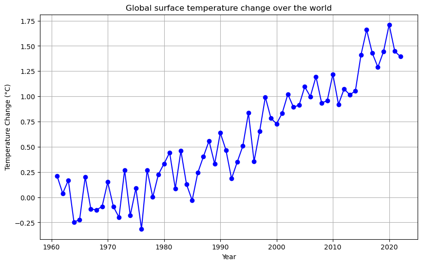

```python
# Filter data for the "World".
world_data = climate_data[climate_data['Country'] == 'World']

# Select temperature columns.
year_columns = [col for col in world_data.columns if col.startswith('F') and col[1:].isdigit()]
years = np.array([int(col[1:]) for col in year_columns])

# Extract years and corresponding temperature values
temperatures = np.array(world_data[year_columns].values.flatten())

# Plotting the global temperature trend
plt.figure(figsize=(10, 6))
plt.plot(years, temperatures, marker='o', linestyle='-', color='b')
plt.title('Global surface temperature change over the world')
plt.xlabel('Year')
plt.ylabel('Temperature Change (°C)')
plt.grid(True)
plt.show()
```

In this practical session, we study the trend of the evolution of world temperature changes by fitting trend model to this data. The fitting procedure will be set using the optimization methods of the scipy package.

### 2. Trend fitting.

### 2.1. The fitting issue.

We assume that the observation can be modeled as

$$ y_i = M_\theta(t_i) + \varepsilon_i, i \in [\![1,n]\!], $$

where

- $M_\theta$ is some parametric function representing a trend,
- and the $\varepsilon_i$ are centered Gaussian random variables representing variations around the trend.

The goal is to find a value of $\theta$ for which the function $F_\theta$ "matches" the data. This is formulated in terms of minimizing a least square criterion of the form

$$ \mathcal{C}(\theta) = \frac{1}{2} \sum_{i=0}^{n} \left( y_i - M_\theta(t_i) \right)^2, $$

over a set $\Theta$ of possible parameter values.

This minimization problem takes different forms depending on the choice of the parametric model.

### 2.2. Fitting polynomial trends.

As a first example of fitting, we choose $M_\theta$ to be linear, and write $$ M_\theta(t) = \theta_0 + \theta_1 \: t. $$

Thus the fitting problem amounts to the miminization of least square criterion

\begin{equation} \label{eqn:linear_lsq} \mathcal{C}_0(\theta) = \frac{1}{2} \sum_{i=0}^{n} \left( y_i - \theta_0 - \theta_1 t_i \right)^2, \end{equation}

for $\theta = (\theta_0, \theta_1)$ varying in $\mathbb{R}^2$.

The solution of this problem can be numerically approximated using the method [lsq_linear](https://docs.scipy.org/doc/scipy/reference/generated/scipy.optimize.lsq_linear.html) from the package scipy.optimize. As explained in the manual, the method is devoted the minimization of so-called linear least square problem of the form

$$ \mathbf{C}_0(x) = \frac{1}{2} \left\vert A x - b \right\vert^2, $$

where

- $A$ stands for a matrix of size $n \times p$, and $b$ for a vector of size $p$,
- $x$ is a variable in $\mathbb{R}^p$ which may be submitted to some constraints,
- $\vert \cdot \vert$ is the Euclidean norm on $\mathbb{R}^p$.

# Exercise 1

# Expressing C_0 in the matricial form of the criterion C_0:

# 1. C_0(theta) = (1/2) * sum((y_i - theta_0 - theta_1 * t_i)^2)

# In matrix form, this can be written as:

# C_0(x) = (1/2) * ||A * x - b||^2

# where A is a matrix of size n x 2 with the first column being all ones and the second column being the time values t_i,

# x is the vector theta = (theta_0, theta_1), and b is the vector of observations y_i.

# 1. Express C_0 in the matricial form of the criterion C_0.

# 2. Apply lsq_linear to minimize C_0.

# 3. Print the obtained minimum and the minimizer.

# 4. On the same graphic, overlay the observation and the values of prediction obtained with the model.

```
Minimum value of the criterion: 1.2539960777114634
Minimizer (theta): [-5.50438856e+01  2.79260155e-02]
```

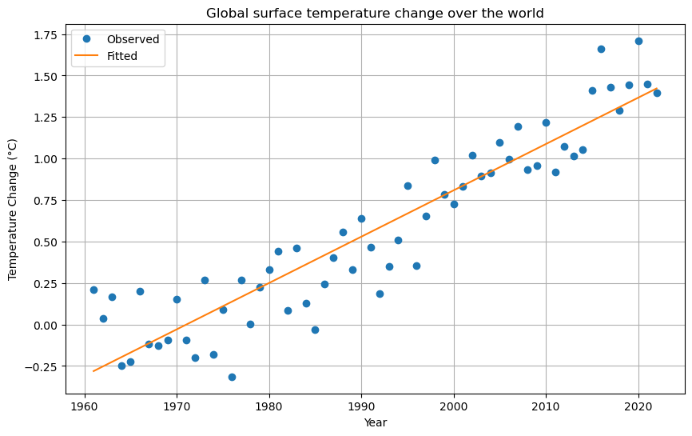

```python
#Exercice 2
#2. Apply `lsq_linear` to minimize \(\mathcal{C}_0\):

#  Construct matrix A and vector b
A = np.vstack([np.ones_like(years), years]).T
b = temperatures

# Apply lsq_linear
res = optim.lsq_linear(A, b)

# Print the obtained minimum and the minimizer
print("Minimum value of the criterion:", res.cost)
print("Minimizer (theta):", res.x)

# Overlay the observation and the values of prediction obtained with the model
plt.figure(figsize=(10, 6))
plt.plot(years, temperatures, 'o', label='Observed')
plt.plot(years, A @ res.x, '-', label='Fitted')
plt.title('Global surface temperature change over the world')
plt.xlabel('Year')
plt.ylabel('Temperature Change (°C)')
plt.legend()
plt.grid(True)
plt.show()
```

**Exercise 2**

1. Extend the previous trend estimation to the fitting of a second-order polynomial trend of the form

$$ M_\theta(t) = \theta_0 + \theta_1 t + \theta_2 t^2. $$

2. Apply the method *lsq_linear* to fit the observations.
3. Compare the obtained fitting with the previous one in terms of minimum.

```
Minimum value of the criterion (second-order polynomial): 1.009999432192055
Minimizer (theta) (second-order polynomial): [ 1.17373031e+03 -1.20619241e+00  3.09846453e-04]
```

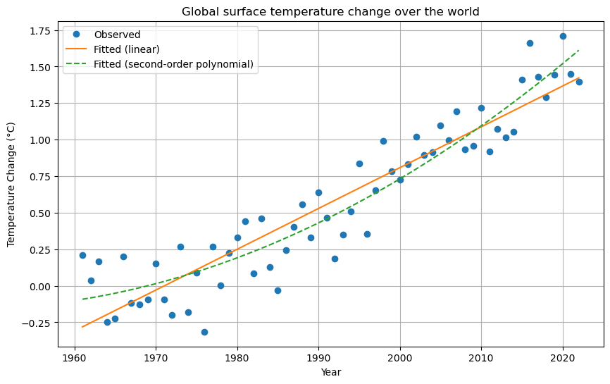

```python
# Construct matrix A for second-order polynomial
A_poly2 = np.vstack([np.ones_like(years), years, years**2]).T

# Apply lsq_linear for second-order polynomial fitting
res_poly2 = optim.lsq_linear(A_poly2, b)

# Print the obtained minimum and the minimizer
print("Minimum value of the criterion (second-order polynomial):", res_poly2.cost)
print("Minimizer (theta) (second-order polynomial):", res_poly2.x)

# Overlay the observation and the values of prediction obtained with the model
plt.figure(figsize=(10, 6))
plt.plot(years, temperatures, 'o', label='Observed')
plt.plot(years, A @ res.x, '-', label='Fitted (linear)')
plt.plot(years, A_poly2 @ res_poly2.x, '--', label='Fitted (second-order polynomial)')
plt.title('Global surface temperature change over the world')
plt.xlabel('Year')
plt.ylabel('Temperature Change (°C)')
plt.legend()
plt.grid(True)
plt.show()
```

### 2.3. Non linear fitting.

In a second approach, we propose to fit the observations with an exponential model of the form

$$ M_\theta(t) = \theta_0 + \theta_1 \exp(\theta_2 t). $$

Thus, we shall minimize a criterion of the form $$ \mathcal{C}_1(\theta) = \frac{1}{2} \sum_{i=1}^n (y_i - \theta_0 - \theta_1 \exp(\theta_2 t_i) )^2, $$ for $\theta = (\theta_0, \theta_1, \theta_2)$ varying in $\mathbb{R}^3$.

For that, we use the method [least_squares](https://docs.scipy.org/doc/scipy/reference/generated/scipy.optimize.least_squares.html) of scipy.optimize. As mentioned in the manual, this method enables to minimize a non-linear least square criterion of the form

$$ \mathbf{C}_1(\theta) = \frac{1}{2} \sum_{i=1}^n (\epsilon_i(\theta))^2, $$

where $\epsilon_n(\theta)$ are some residuals that have to be defined by the user.To apply the method *least_square* to our problem, we should set

$$ \epsilon_i(\theta) = y_i - \theta_0 - \theta_1 \exp(\theta_2 t_i). $$

**Exercise 3**

1. Compute mathematically the jacobian matrix of the function:

$$ \begin{array}{cccc} \epsilon & \mathbb{R}^3 & \rightarrow & \mathbb{R}^n \\ & \theta & \rightarrow & (\epsilon_1(\theta), \cdots, \epsilon_n(\theta)). \end{array} $$

2. Following the templates below, write three numpy functions that returns
   - the value of the exponential model at given times $t$,
   - the residual of the exponential model at given times $t$,
   - the jacobian of the residuals of the exponential model at given times $t$.

```
**Exercise 3**

1. Compute mathematically the jacobian matrix of the function:

$$ \begin{array}{cccc}
\epsilon & \mathbb{R}^3 & \rightarrow  & \mathbb{R}^n \\
& \theta & \rightarrow & (\epsilon_1(\theta), \cdots, \epsilon_n(\theta)).
\end{array} $$

The residuals are given by:

$$ \epsilon_i(\theta) = y_i -  \theta_0 - \theta_1 \exp(\theta_2 t_i). $$

The Jacobian matrix \(J\) of the residuals with respect to \(\theta\) is:

$$ J_{ij} = \frac{\partial \epsilon_i}{\partial \theta_j} $$

Thus, the partial derivatives are:

$$ \frac{\partial \epsilon_i}{\partial \theta_0} = -1 $$
$$ \frac{\partial \epsilon_i}{\partial \theta_1} = -\exp(\theta_2 t_i) $$
$$ \frac{\partial \epsilon_i}{\partial \theta_2} = -\theta_1 t_i \exp(\theta_2 t_i) $$

So, the Jacobian matrix \(J\) is:

$$ J = \begin{pmatrix}
-1 & -\exp(\theta_2 t_1) & -\theta_1 t_1 \exp(\theta_2 t_1) \\
-1 & -\exp(\theta_2 t_2) & -\theta_1 t_2 \exp(\theta_2 t_2) \\
\vdots & \vdots & \vdots \\
-1 & -\exp(\theta_2 t_n) & -\theta_1 t_n \exp(\theta_2 t_n)
\end{pmatrix} $$

2. Following the templates below, write three numpy functions that return
    - the value of the exponential model at given times \(t\),
    - the residual of the exponential model at given times \(t\),
    - the Jacobian of the residuals of the exponential model at given times \(t\).
```

```python
def exponential_model(theta, t):
    """Exponential model.

    Parameters
    ----------
    theta : array
        Model parameters
    t : array
        Observation times.

    Returns
    -------
       Values of the exponential model at times t.
    """
    return theta[0] + theta[1] * np.exp(theta[2] * t)

def res_exponential_model(theta, t, w):
    """Residual of the exponential fitting.

    Parameters
    ----------
    theta : array
        Model parameters
    t : array
        Observation points.
    w: array
        Observation values.

    Returns
    -------
        Residuals at times t.
    """
    return w - exponential_model(theta, t)

def jac_res_exponential_model(theta, t, w):
    """Jacobian of residual of the exponential fitting.
    Parameters
    ----------
    theta : array
        Model parameters
    t : array
        Observation points.
    w: array
        Observation values.

    Returns
    -------
        The jacobian matrix of residuals at times t.
    """
    J = np.zeros((t.size, theta.size))
    J[:, 0] = -1
    J[:, 1] = -np.exp(theta[2] * t)
    J[:, 2] = -theta[1] * t * np.exp(theta[2] * t)
    return J
    #print("Jacobian of the residual of the exponential model:", jac_res_exponential_model(res_exp.x, years, temperatures))
```

**Exercise 4** **Solution to Exercise 4**

1. Using the function above, apply the method *least_square* to fit observations with an exponential model.

[output not shown]

```
Minimum value of the criterion (exponential): 1.0391143658297977
Minimizer (theta) (exponential): [-9.51753218e-01  7.53708135e-17  1.88239826e-02]
```

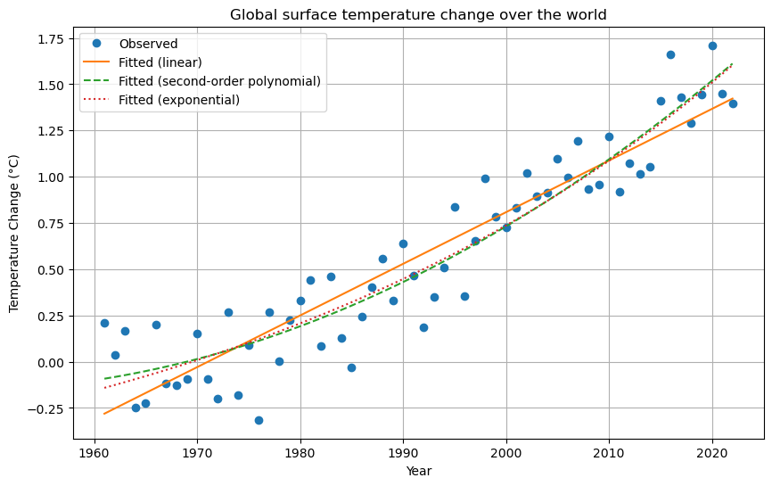

```python
res_exp = optim.least_squares(res_exponential_model, x0=[0, 0, 0], jac=jac_res_exponential_model, args=(years, temperatures))

# Print the obtained minimum and the minimizer
print("Minimum value of the criterion (exponential):", res_exp.cost)
print("Minimizer (theta) (exponential):", res_exp.x)

# Overlay the observation and the values of prediction obtained with the model
plt.figure(figsize=(10, 6))
plt.plot(years, temperatures, 'o', label='Observed')
plt.plot(years, A @ res.x, '-', label='Fitted (linear)')
plt.plot(years, A_poly2 @ res_poly2.x, '--', label='Fitted (second-order polynomial)')
plt.plot(years, exponential_model(res_exp.x, years), ':', label='Fitted (exponential)')
plt.title('Global surface temperature change over the world')
plt.xlabel('Year')
plt.ylabel('Temperature Change (°C)')
plt.legend()
plt.grid(True)
plt.show()
```

2. Compare the predictions to those obtained by polynomial fittings.

The exponential model provides a different perspective on the trend compared to the linear and second-order polynomial models. By overlaying the predictions from all three models, we can visually compare their fits to the observed data. The exponential model may capture certain aspects of the trend that the polynomial models do not, especially if the temperature changes exhibit exponential growth characteristics. However, the best model should be chosen based on the minimum value of the criterion and the goodness of fit to the observed data.

```
### Conclusion

In this practical session, we explored the use of the `optimize` library from the `Scipy` package to fit trend models to climate data. We applied both linear and non-linear optimization methods to analyze the trend of global surface temperature changes from 1961 to 2022.

We started by fitting a linear trend model using the `lsq_linear` method, which provided a basic understanding of the temperature trend over the years. We then extended this approach to fit a second-order polynomial trend, which offered a more flexible model to capture potential non-linearities in the data.

Finally, we applied the `least_squares` method to fit an exponential model, allowing us to explore non-linear trends in the temperature changes. By comparing the results of the linear, polynomial, and exponential models, we gained insights into the different characteristics of each model and their ability to capture the underlying trend in the data.

Overall, this TP demonstrated the power and versatility of the `Scipy` optimization methods for trend analysis in climate studies. The choice of the best model depends on the specific characteristics of the data and the desired level of complexity in the trend representation. The practical session provided valuable hands-on experience in applying these methods to real-world data, enhancing our understanding of both the mathematical concepts and their practical applications.
```